# Stack Plot

Load in the modules and set the working directory.

```r
library(ggplot2)
library(gridExtra)

setwd("~/Development/other_people_help/Annnabelle/stackplot")
```

First step is to read in your data and then split (using `split()`) the data frame up into five smaller data frames based on body parts. The results will be saved to a list of length 5 (`df.ls`) and each element will be a seperate data frame.

```r
df <- read.csv("dfanalysis.csv")
df.ls <- split(df, df$Body.Part)
```

Okay, now we define a function to make our plots. It will be applied to each dataframe within the data frame list (`df.ls`).

```r
plot.stack <- function(df){
  df <- df[!(df$Entanglement.Score==4),] # drop score 4
  df <- df[order(df$Year,df$Entanglement.Score),] # order the list based on year then score
  ggplot(df ,aes(x = Year, y = Entanglement.Score ,fill = as.factor(Entanglement.Score))) +
    geom_bar(position = "fill", stat = "identity") +
    ggtitle(df$FLKbase[1]) # set title
}
```

The using `lapply()` we apply the function to every elment of the list and end up with a list of the plots (`plot.ls`).

```r
plot.ls <- c(lapply(df.ls, plot.stack))
```

Then we work out how many plots we have and calculate how many columns we need and use the `grid.arrange()` function to plot them all together.

```r
n <- length(plot.ls)
ncol <- floor(sqrt(n))
```

And there ya have it. You might want to modify the legend and axis titles but that should be easy. In this example though I’m just calling `plot.ls` so they come out properly in the html doc. Normally I would use `do.call("grid.arrange", c(plot.ls, ncol=ncol))`

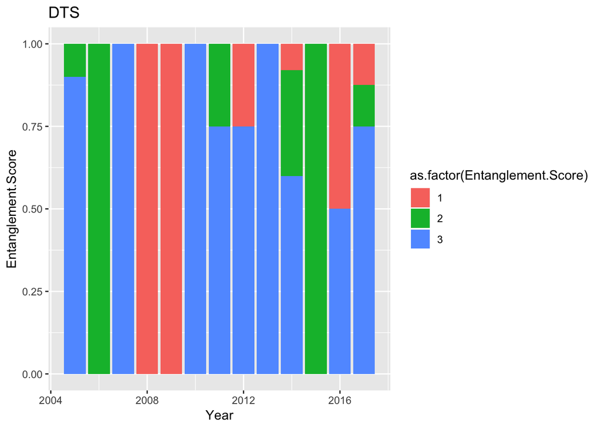

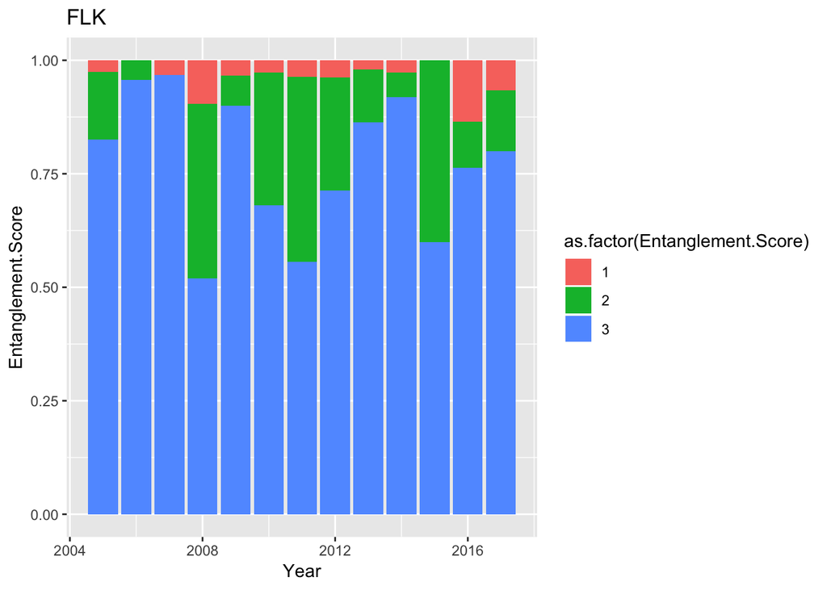

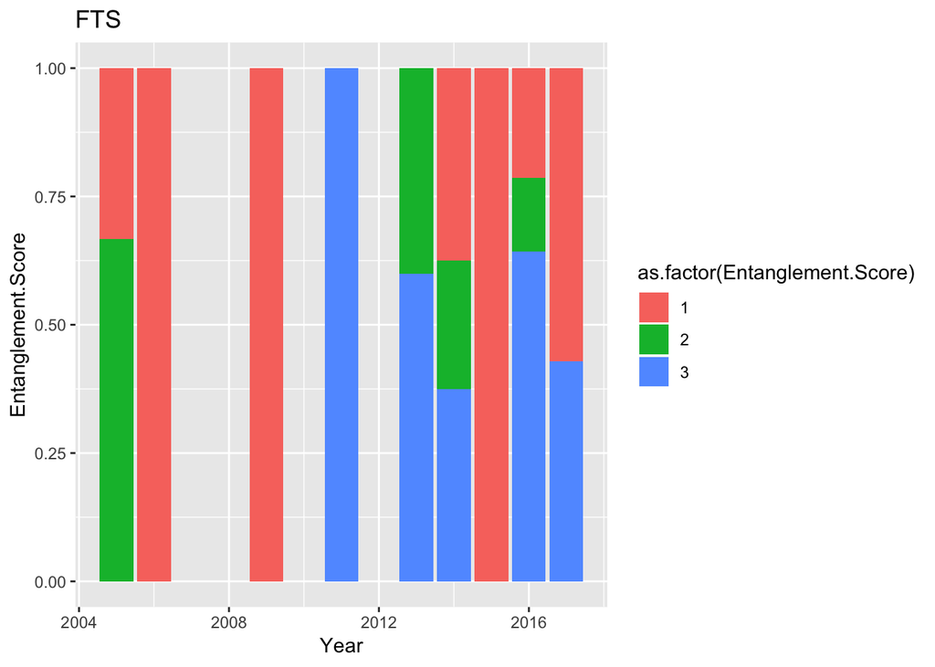

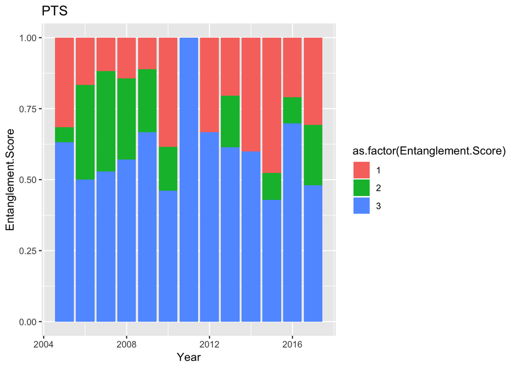

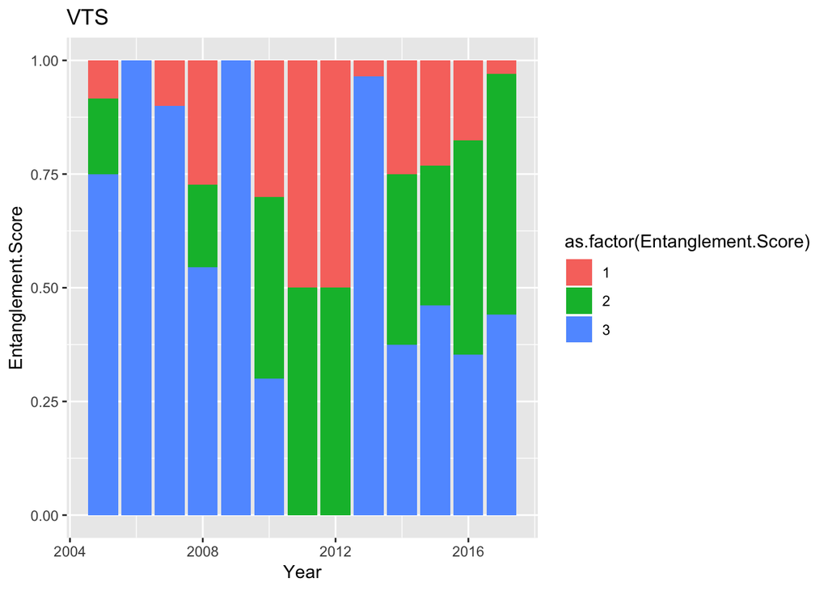

```r
# using plot.ls instead of do.call("grid.arrange", c(plot.ls, ncol=ncol))
plot.ls
```